# R Notebook

```r
library(readr)
library(dplyr)
library(tidyr)
library(stringr)
library(glmnet)
library(ggplot2)
library(gmodels)
library(epitools)
library(DescTools)
library(vcd)
library(ggpubr)
library(vcdExtra)
library(nortest)
library(car)
```

# Question Set 1

The data set sales is a training data set that contains information for daily sales from a large franchise. The data set contains randomly selected days from 400 locations to measure the impact of holidays, weekends, population size, layout of store, number of years of operation of store and state on sales. The goal is to find the best linear predictor (do NOT use higher order terms…NO power terms or interactions). Since this is a training data set, you do not need to split this data. The data is organized as follows:

holiday: 1 = holiday and 0= not a holiday

weekend: 1 = weekend and 0 = weekday

pop: population size in 10,000s

display: layout of the store with 1 = custom design and 0 = recommended design

open: number of years the location was in operation

state: the state in which the store is located with 1 = Georgia, 2 = North Carolina, 3 = South Carolina and 4 = Georgia

y: Daily sales amount

Be aware of data formats! For any statistical tests, use a significance level of 0.05.

```r
sales <- read_csv('https://raw.githubusercontent.com/IAA-Faculty/statistical_foundations/master/sales_train.csv')
```

```r
head(sales)
```

| holiday | weekend | pop | display | open | state | y |
| --- | --- | --- | --- | --- | --- | --- |
| 0 | 0 | 99 | 0 | 14 | 1 | 501.4332 |
| 0 | 0 | 91 | 1 | 15 | 1 | 490.4989 |
| 0 | 0 | 84 | 0 | 19 | 1 | 482.6543 |
| 0 | 1 | 73 | 0 | 13 | 1 | 476.0139 |
| 0 | 0 | 98 | 1 | 17 | 1 | 493.0711 |
| 1 | 0 | 81 | 1 | 14 | 1 | 494.1661 |

```r
sales$holiday <- as.factor(sales$holiday)
sales$weekend <- as.factor(sales$weekend)
sales$display <- as.factor(sales$display)
sales$state <- as.factor(sales$state)
```

## Question 2

Calculate the GVIF used in assessing multicollinearity. Report the highest GVIF value from this regression (be sure to look at the correct column). Round to two decimal places.

```r
sales_lm <- lm(y ~ holiday + weekend + pop + display + open + state, data = sales)
car::vif(sales_lm)
```

```
            GVIF Df GVIF^(1/(2*Df))
holiday 1.023109  1        1.011488
weekend 1.010917  1        1.005444
pop     1.015094  1        1.007518
display 1.023347  1        1.011606
open    1.010793  1        1.005382
state   1.040852  3        1.006696
```

Answer: 1.04

## Question 3

Based on the GVIF values calculated in Question 1, is multicollinearity an issue? Explain why or why not.

Answer: No. Multicollinearity is typically signaled by a VIF above 10. All of the variables here have low VIFs, so we should not expect significant multicollinearity.

## Question 4

Perform a forward selection using AIC (do NOT include any higher order terms or interactions). Write out the model. In other words, y-hat =… (be sure to include coefficient values).

```r
sales_empty <- lm(y ~ 1, data = sales)

sales_forward <- step(sales_empty, scope = list(lower = sales_empty, upper = sales_lm), direction = "forward", k = 2)
```

```
Start:  AIC=1846.1
y ~ 1

          Df Sum of Sq   RSS    AIC
+ pop      1     33613  6591 1124.8
+ display  1      1335 38869 1834.6
+ holiday  1      1223 38981 1835.8
<none>                 40204 1846.1
+ weekend  1        54 40150 1847.6
+ open     1         5 40199 1848.0
+ state    3       146 40058 1850.7

Step:  AIC=1124.78
y ~ pop

          Df Sum of Sq    RSS    AIC
+ holiday  1   1592.84 4997.9 1016.1
+ display  1    508.48 6082.3 1094.7
+ state    3     98.48 6492.3 1124.8
<none>                 6590.8 1124.8
+ weekend  1      1.17 6589.6 1126.7
+ open     1      0.57 6590.2 1126.8

Step:  AIC=1016.13
y ~ pop + holiday

          Df Sum of Sq    RSS     AIC
+ display  1    575.21 4422.7  969.22
<none>                 4997.9 1016.13
+ open     1      4.54 4993.4 1017.76
+ weekend  1      3.64 4994.3 1017.83
+ state    3     34.94 4963.0 1019.32

Step:  AIC=969.22
y ~ pop + holiday + display

          Df Sum of Sq    RSS    AIC
<none>                 4422.7 969.22
+ open     1   10.7983 4411.9 970.24
+ weekend  1    0.6777 4422.0 971.16
+ state    3   29.4771 4393.2 972.54
```

```r
summary(sales_forward)
```

```
Call:
lm(formula = y ~ pop + holiday + display, data = sales)

Residuals:
     Min       1Q   Median       3Q      Max
-10.9898  -1.9560  -0.1169   2.3437  10.6340

Coefficients:
             Estimate Std. Error t value Pr(>|t|)
(Intercept) 401.95383    1.47761 272.030  < 2e-16 ***
pop           0.97959    0.01799  54.460  < 2e-16 ***
holiday1      9.58563    0.78636  12.190  < 2e-16 ***
display1     -2.40706    0.33541  -7.177 3.55e-12 ***
---
Signif. codes:  0 ‘***’ 0.001 ‘**’ 0.01 ‘*’ 0.05 ‘.’ 0.1 ‘ ’ 1

Residual standard error: 3.342 on 396 degrees of freedom
Multiple R-squared:   0.89, Adjusted R-squared:  0.8892
F-statistic:  1068 on 3 and 396 DF,  p-value: < 2.2e-16
```

Answer: y-hat = 0.980 * pop + 9.586 * holiday + -2.407 * display + 401.954

## Question 5

Check the Normality assumption for the linear model from the forward selection. What did you use to assess Normality (be specific…what values did you use? Did you use a test or a graph? What test or what graph? What did it look like to help you make your decision). What was your decision?

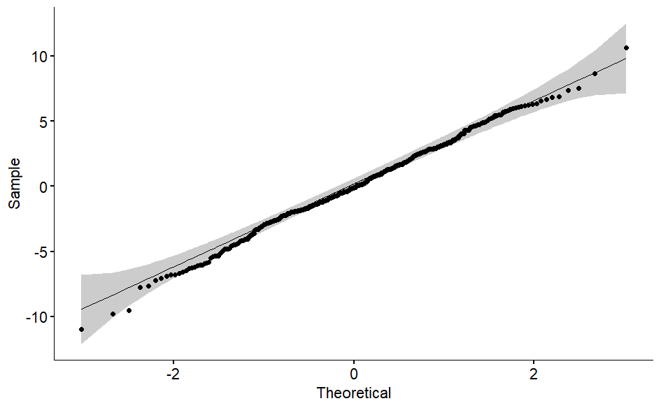

```r
ggqqplot(residuals(sales_forward))
```

```r
shapiro.test(residuals(sales_forward))
```

```
    Shapiro-Wilk normality test

data:  residuals(sales_forward)
W = 0.99679, p-value = 0.6147
```

```r
ad.test(residuals(sales_forward))
```

```
    Anderson-Darling normality test

data:  residuals(sales_forward)
A = 0.39505, p-value = 0.3708
```

Answer: The linear model appears normal. To determine this I looked at a QQ plot to ensure there were no significant deviations from the expected straight line. I also ran a Shapiro-Wilk (p = 0.615) and Anderson-Darling test (p = 0.371) to have a formal test, with both indicating that we could not reject the null.

## Question 6

Assess the homoscedasticity of variance assumption of the forward selection model. What did you use to make this decision and what was your conclusion.

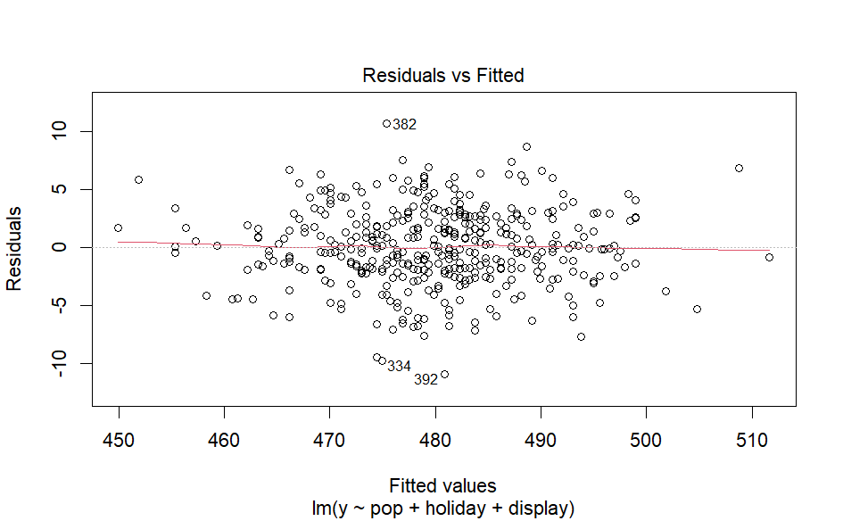

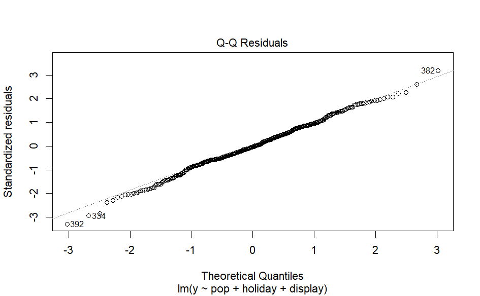

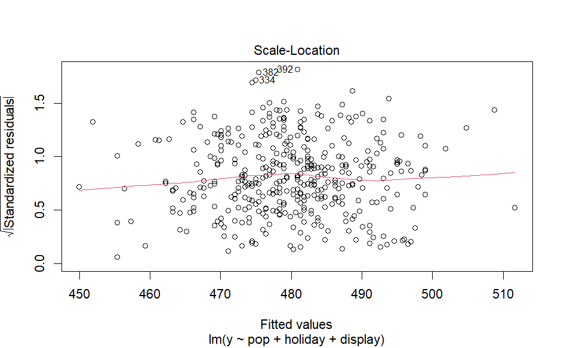

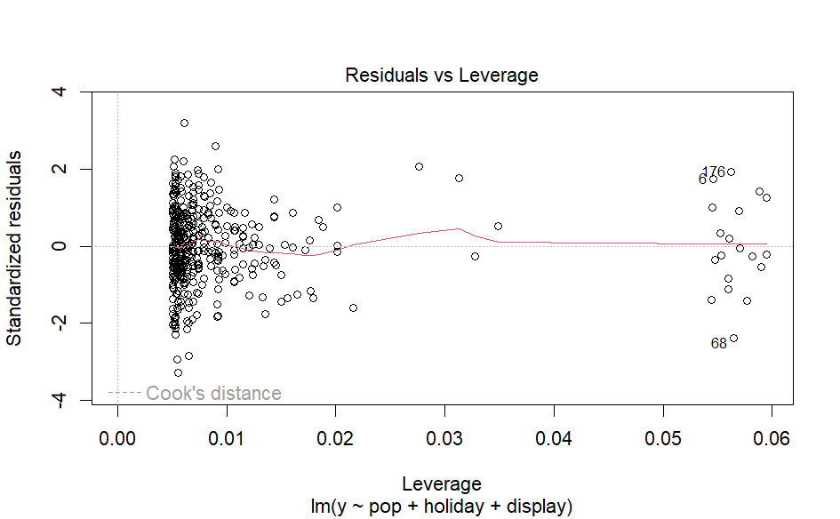

```r
plot(sales_forward)
```

Answer: The model appears homoscedastic. To evaluate this, I used plot(sales_forward) in R to generate a plot of the model residuals against fitted values. The residuals appeared to be plotted randomly, with no notable patterns indicating changes in variance across the fitted values. The plot of standardized residuals also shows no notable pattern.

## Question 7

There does not appear to be a pattern in the residual plot which means the assumption of linearity in the means is a reasonable assumption.

Answer: True